# OBJETIVO 1 - PROY

celia

2025-05-03

# Introducción

Este proyecto trata sobre la calidad del aire en las diferentes ciudades europeas. El estudio consistirá en analizar la contaminación ambiental de distintos sectores según sus emisiones en las distintas ciudades europeas, así como su contribución en el PM 2.5 (materia particulada: partículas muy pequeñas en el aire que tienen un diámetro de 2.5 micrómetros). Además del estudio de otros factores que pueden afectar a la calidad del aire.

## Objetivos

OBJETIVO I. Cuantificar y caracterizar la contaminación generada por los principales sectores en Europa.

OBJETIVO II. Identificar los sectores con huella directa ciudadana y su impacto en la calidad del aire urbana.

OBJETIVO III. Evaluar el impacto de los aeropuertos en la contaminación urbana comparando 50 ciudades con aeropuerto frente a 50 sin aeropuerto, cuyas ciudades compartan características demográficas similares.

OBJETIVO IV. Estimar un índice de contaminación por país y analizar el resto de sectores que no tienen relación directa con la huella ciudadana como las industrias o la agricultura.

OBJETIVO V. Comparar patrones de calidad del aire entre regiones europeas con distintas características geográficas y demográficas.

## PRIMER OBJETIVO: Cuantificar y caracterizar la contaminación generada por los principales sectores en Europa.

Analizar los perfiles de emisiones de cada sector en las principales ciudades europeas, analizando los distintos gases contaminantes emitidos (NH₃, COVDM, NOₓ, PM2,5, SOₓ). Se busca entender qué tipo de gases son característicos para cada sector, cuál es el sector más contaminante y que sectores contaminan más a la calidad del aire de las ciudades.

#### Gases:

NH3 = amoniaco

COVDM = emisiones de compuestos orgánicos volátiles distintos del metano

NOx = óxidos de nitrógeno (puede ser óxido nítrico o dióxido de nitrógeno)

PM2.5 = materia particulada (son partículas muy pequeñas en el aire que tiene un diámetro de 2.5 micrómetros de diámetro o menos)

SOx = óxidos de azufre

# 1. DATOS USADOS Y FUENTES

## LECTURA DE DATOS

Partimos de una base de datos inicial, llamada Ciudades_origen_gases, la cual está medianamente tratada y no tenemos datos nulos, sin embargo tenemos un exceso de datos (174900). Vamos a realizar un estudio de las variables. Las variables son:

- **CIUDAD**: Nombre de la ciudad donde se realiza la medición.
- **EXTRACCION**: Identificador de extracción de datos para la ciudad (Ciudad, Comunidad, Nacional e Internacional)
- **SECTOR**: Código numérico que indica el sector de origen de la emisión (cada numero corresponde con un sector “Agricultura, Shipping, Transporte, Industria…”)
- **GAS**: Tipo de gas emitido (NH₃, NMVOC, NOₓ, PM2.5, SOₓ).
- **POTENCIAL**: porcentaje de la concentración media anual de PM2,5 puede atribuirse a un determinado precursor (como el NH₃ o NOₓ) emitido por un sector específico. Si el sector “Agricultura” emite NH₃ y su POTENCIAL es 20%, significa que el 20% del PM₂.₅ en esa ciudad se forma a partir de las reacciones químicas del NH₃ agrícola.

## HITO 2

```r
library(readxl)
library(dplyr)
library(tidyr)
library(reshape2)
```

```r
library(ggplot2)
library(writexl)
library(knitr)
library(stringr)
library(rvest)
library(xml2)
df <- read_excel("Ciudades_origen_gases.xlsx")
summary(df)
```

```
##     CIUDAD           EXTRACCION            SECTOR          GAS
##  Length:174900      Length:174900      Min.   : 1.00   Length:174900
##  Class :character   Class :character   1st Qu.: 3.75   Class :character
##  Mode  :character   Mode  :character   Median : 6.50   Mode  :character
##                                        Mean   : 6.50
##                                        3rd Qu.: 9.25
##                                        Max.   :12.00
##    POTENCIAL
##  Min.   :-2.3035
##  1st Qu.: 0.0000
##  Median : 0.0066
##  Mean   : 0.3636
##  3rd Qu.: 0.1213
##  Max.   :41.4720
```

```r
head(df, 5)              # Primeras 5 filas
```

| CIUDAD | EXTRACCION | SECTOR | GAS | POTENCIAL |
| --- | --- | --- | --- | --- |
| A Coruña | A Coruña_City | 1 | NH3 | 0.0252 |
| A Coruña | A Coruña_City | 1 | NMVOC | 0.0093 |
| A Coruña | A Coruña_City | 1 | NOx | 0.1226 |
| A Coruña | A Coruña_City | 1 | PPM25 | 0.1631 |
| A Coruña | A Coruña_City | 1 | SOx | 0.0143 |

```r
df[60:65, ]              # Filas 60 a 65
```

| CIUDAD | EXTRACCION | SECTOR | GAS | POTENCIAL |
| --- | --- | --- | --- | --- |
| A Coruña | A Coruña_City | 12 | SOx | 0.0000 |
| A Coruña | A Coruña_Comm | 1 | NH3 | 0.0437 |
| A Coruña | A Coruña_Comm | 1 | NMVOC | 0.0159 |
| A Coruña | A Coruña_Comm | 1 | NOx | 0.2021 |
| A Coruña | A Coruña_Comm | 1 | PPM25 | 0.2913 |
| A Coruña | A Coruña_Comm | 1 | SOx | 0.0559 |

```r
df[177:182, ]            # Filas 177 a 182
```

| CIUDAD | EXTRACCION | SECTOR | GAS | POTENCIAL |
| --- | --- | --- | --- | --- |
| A Coruña | A Coruña_National | 12 | NMVOC | -0.0060 |
| A Coruña | A Coruña_National | 12 | NOx | 0.0006 |
| A Coruña | A Coruña_National | 12 | PPM25 | 0.1378 |
| A Coruña | A Coruña_National | 12 | SOx | 0.0005 |
| Aachen | Aachen_City | 1 | NH3 | 0.0019 |
| Aachen | Aachen_City | 1 | NMVOC | 0.0029 |

#### Preparación base de datos

La variable **EXTRACCION** tiene 4 identificadores distintos `(Ciudad, Comunidad, Nacional e Internacional)`. El `Internacional` queda descartado porque como vemos en el primer muestreo, “A Coruña” no tiene ese tipo.

**Desviación estándar:** Cuanto mayor sea, más dispersos están los datos.  
**Coeficiente de variación:** Un valor alto indica mayor variabilidad relativa.  
**Rango:** Un rango amplio sugiere más diversidad en los valores.

Como uno de los objetivos es el cruce de ciertas variables para hacer un PCA, nos interesa elegir la categoría que tenga mayor variabilidad y permita distinguir diferencias significativas entre los datos.

Entonces filtramos para incluir solo extracciones “City”, y el resultado será una nueva base de datos llamada gases_city.

En esta nueva base de datos tendremos las variables:

- **CIUDAD**: Nombre de la ciudad donde se realiza la medición.
- **SECTOR**: Código numérico que indica el sector de origen de la emisión (1-12)
- **GAS**: Tipo de gas emitido (NH₃, NMVOC, NOₓ, PM2.5, SOₓ).
- **POTENCIAL**: porcentaje de la concentración media anual de PM2,5 puede atribuirse a un determinado precursor (como el NH₃ o NOₓ) emitido por un sector específico.

#### SECTORES:

1. Public Power: energía pública.
2. Industry: industria
3. Other stationary combustion: Otros tipos de combustión estacionaria
4. Fugitives: fugitivos
5. Solvents: disolventes
6. Road transportation: transporte de carretera
7. Shipping: transporte marítimo
8. Aviation: aviación
9. Off road transportation: transporte todoterreno
10. Waste: residuos
11. Agriculture livestock: agricultura y ganadería
12. Agriculture other: otros tipos de agricultura

# 2. LEER EXCEL NUEVO Y TRANSFORMACIONES

Conversión de la variable POTENCIAL a numérico (cambiar comas por puntos).

```r
library(readxl)
library(dplyr)


df <- read_excel("gases_city.xlsx")

# Corregir formato decimal y convertir a numérico
df <- df %>%
  mutate(POTENCIAL = as.numeric(gsub(",", ".", POTENCIAL)))
summary(df)
```

```
##     CIUDAD              SECTOR          GAS              POTENCIAL
##  Length:44820       Min.   : 1.00   Length:44820       Min.   :-0.5359
##  Class :character   1st Qu.: 3.75   Class :character   1st Qu.: 0.0000
##  Mode  :character   Median : 6.50   Mode  :character   Median : 0.0020
##                     Mean   : 6.50                      Mean   : 0.2154
##                     3rd Qu.: 9.25                      3rd Qu.: 0.0651
##                     Max.   :12.00                      Max.   :34.0570
```

# 3. PLANTEAMIENTO DE LA SOLUCIÓN

El objetivo es *descriptivo*, buscando:

- Identificar sectores más contaminantes y gases asociados.

**Técnicas aplicadas**:

- Agrupación de datos por sector y gas.
- Visualizaciones (barras, heatmaps, facetado).
- PCA para reducir dimensionalidad y explorar relaciones entre sectores y gases.

Agrupar por sector y gas y sumar las emisiones: para ver qué gas afecta más a cada sector.

```r
emisiones_por_sector <- df %>%
  group_by(SECTOR, GAS) %>%
  summarise(Total_Emisiones = sum(POTENCIAL, na.rm = TRUE)) %>%
  arrange(SECTOR, desc(Total_Emisiones))
# Mostrar los primeros resultados
print(emisiones_por_sector)
```

```
## # A tibble: 60 × 3
## # Groups:   SECTOR [12]
##    SECTOR GAS   Total_Emisiones
##     <dbl> <chr>           <dbl>
##  1      1 SOx            297.
##  2      1 NOx            179.
##  3      1 PPM25           81.3
##  4      1 NH3              5.73
##  5      1 NMVOC            2.04
##  6      2 SOx            940.
##  7      2 PPM25          699.
##  8      2 NOx            252.
##  9      2 NH3             48.2
## 10      2 NMVOC           24.1
## # ℹ 50 more rows
```

### PERFILES DE EMISIÓN POR CIUDAD (no incorporar en el objetivo)

```r
# Total de emisiones por CIUDAD y GAS: para ver qué gas es más contaminante en cada ciudad
emisiones_ciudad_gas <- df %>%
  group_by(CIUDAD, GAS) %>%
  summarise(Total_Emisiones = sum(POTENCIAL, na.rm = TRUE)) %>%
  arrange(CIUDAD, desc(Total_Emisiones))
print(emisiones_ciudad_gas)
```

```
## # A tibble: 3,735 × 3
## # Groups:   CIUDAD [747]
##    CIUDAD           GAS   Total_Emisiones
##    <chr>            <chr>           <dbl>
##  1 's-Gravenhage    PPM25          2.63
##  2 's-Gravenhage    NH3            1.67
##  3 's-Gravenhage    NOx            1.51
##  4 's-Gravenhage    NMVOC          0.174
##  5 's-Gravenhage    SOx            0.0977
##  6 's-Hertogenbosch PPM25          2.31
##  7 's-Hertogenbosch NOx            1.74
##  8 's-Hertogenbosch NH3            1.43
##  9 's-Hertogenbosch NMVOC          0.0904
## 10 's-Hertogenbosch SOx            0.0593
## # ℹ 3,725 more rows
```

```r
# tampoco poner en la memoria del objetivo
# Total de emisiones por CIUDAD y SECTOR: para ver qué sector es el más contaminante

emisiones_ciudad_sector <- df %>%
  group_by(CIUDAD, SECTOR) %>%
  summarise(Total_Emisiones = sum(POTENCIAL, na.rm = TRUE)) %>%
  arrange(CIUDAD, desc(Total_Emisiones))
print(emisiones_ciudad_sector)
```

```
## # A tibble: 8,964 × 3
## # Groups:   CIUDAD [747]
##    CIUDAD        SECTOR Total_Emisiones
##    <chr>          <dbl>           <dbl>
##  1 's-Gravenhage      5          1.84
##  2 's-Gravenhage      6          1.44
##  3 's-Gravenhage      3          0.679
##  4 's-Gravenhage      2          0.541
##  5 's-Gravenhage     12          0.521
##  6 's-Gravenhage      7          0.428
##  7 's-Gravenhage      9          0.341
##  8 's-Gravenhage     10          0.167
##  9 's-Gravenhage     11          0.0917
## 10 's-Gravenhage      1          0.0257
## # ℹ 8,954 more rows
```

### 4. DESARROLLO TÉCNICO: VISUALIZACIÓN

*SECTORES:*

1. Public Power: energía pública.
2. Industry: industria
3. Other stationary combustion: Otros tipos de combustión estacionaria
4. Fugitives: fugitivos
5. Solvents: disolventes
6. Road transportation: transporte de carretera
7. Shipping: transporte marítimo
8. Aviation: aviación
9. Off road transportation: transporte todoterreno
10. Waste: residuos
11. Agriculture livestock: agricultura y ganadería
12. Agriculture other: otros tipos de agricultura

## Gráfico de barras apiladas

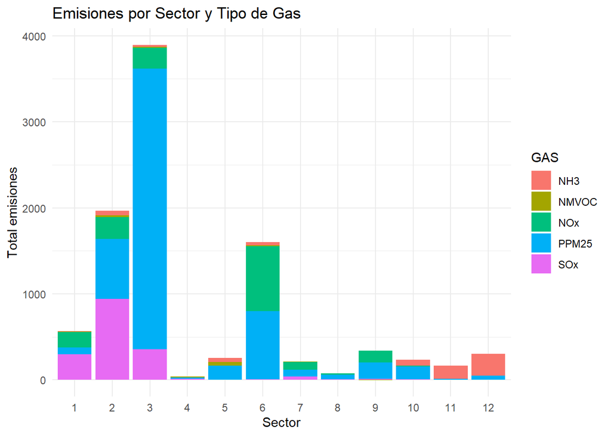

```r
library(ggplot2)

# Gráfico: emisiones por sector y gas
ggplot(emisiones_por_sector, aes(x = factor(SECTOR), y = Total_Emisiones, fill = GAS)) +
  geom_bar(stat = "identity", position = "stack") +
  labs(title = "Emisiones por Sector y Tipo de Gas", x = "Sector", y = "Total emisiones") +
  theme_minimal()
```

### INTERPRETACIÓN GRAFICO

#### **SECTORES MÁS CONTAMINANTES**

- El sector más contaminante es el 3, correspondiente a Otros tipos de combustión estacionaria (emisiones de combustibles quemados en equipos estacionarios, como es el caso de la combustión de petróleo o gas en un sistema de calefacción local). Este sector se ve afectado sobretodo por el PM2,5 (Material Particulado Fino) y un poco de óxidos de azufre (SOx) y óxidos de nitrógeno (NOx)
- Otro de los sectores más contaminantes es el 2 (Industria). Que también emite grandes cantidades de Sox, PM2,5 y NOx por los procesos de fabricación y combustión.
- El tercer sector más contaminante es el 6 (transporte de carretera), donde predomina en la emisión de NOₓ y PM2,5, derivado de motores de combustión.
- Otro sector también muy contaminante aunque menos que los anteriores es el de la energía pública (1). Uno de los principales emisores, especialmente de SOₓ y NOₓ, debido a la quema de combustibles fósiles.

## Gráfico de barras agrupadas: emisiones por gas en cada sector

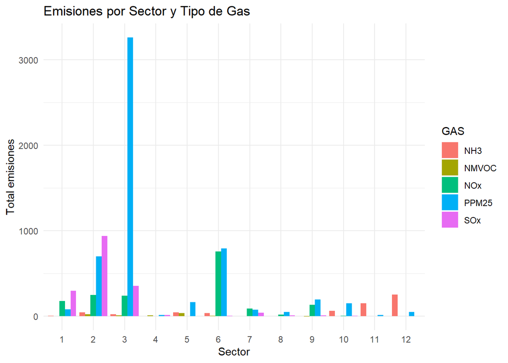

```r
ggplot(emisiones_por_sector, aes(x = factor(SECTOR), y = Total_Emisiones, fill = GAS)) +
  geom_bar(stat = "identity", position = position_dodge()) +
  labs(title = "Emisiones por Sector y Tipo de Gas",
       x = "Sector",
       y = "Total emisiones") +
  theme_minimal()
```

**Principales contaminantes por sector**

1. PM2,5 (Material Particulado Fino): Emitido por todos los sectores aunque los que más lo emiten son: Combustión estacionaria, Transporte de carreteras Industria, con efectos en salud respiratoria.
2. NOₓ (Óxidos de Nitrógeno): Alto en Energía pública, Industria y Transporte de carretera, afectando directamente la calidad del aire urbano.
3. SOₓ (Óxidos de Azufre): Proviene principalmente de la Industria, la Energía pública y combustión estacionaria, también presente en Transporte Marítimo, contribuyendo a la lluvia ácida.

#### Gráfico de líneas por gas a lo largo de sectores

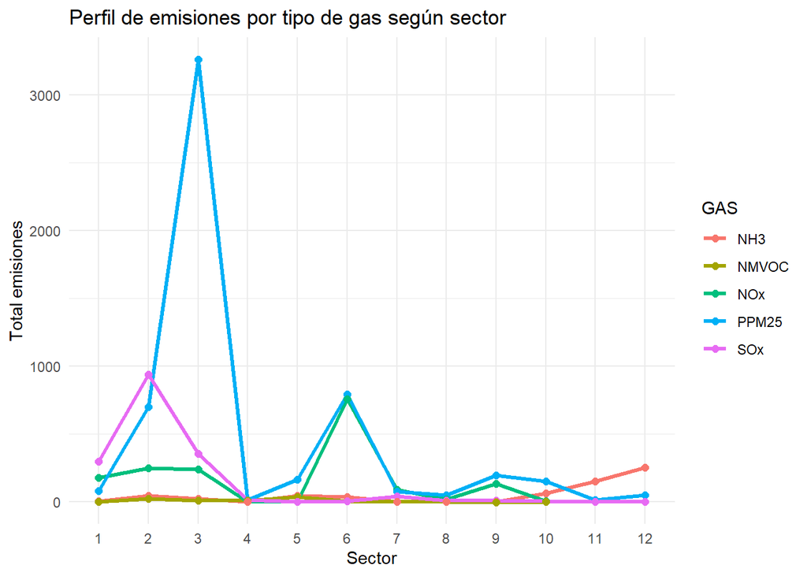

```r
ggplot(emisiones_por_sector, aes(x = factor(SECTOR), y = Total_Emisiones, color = GAS, group = GAS)) +
  geom_line(size = 1.2) +
  geom_point(size = 2) +
  labs(title = "Perfil de emisiones por tipo de gas según sector",
       x = "Sector",
       y = "Total emisiones") +
  theme_minimal()
```

#### Facetado: un gráfico de barras por gas

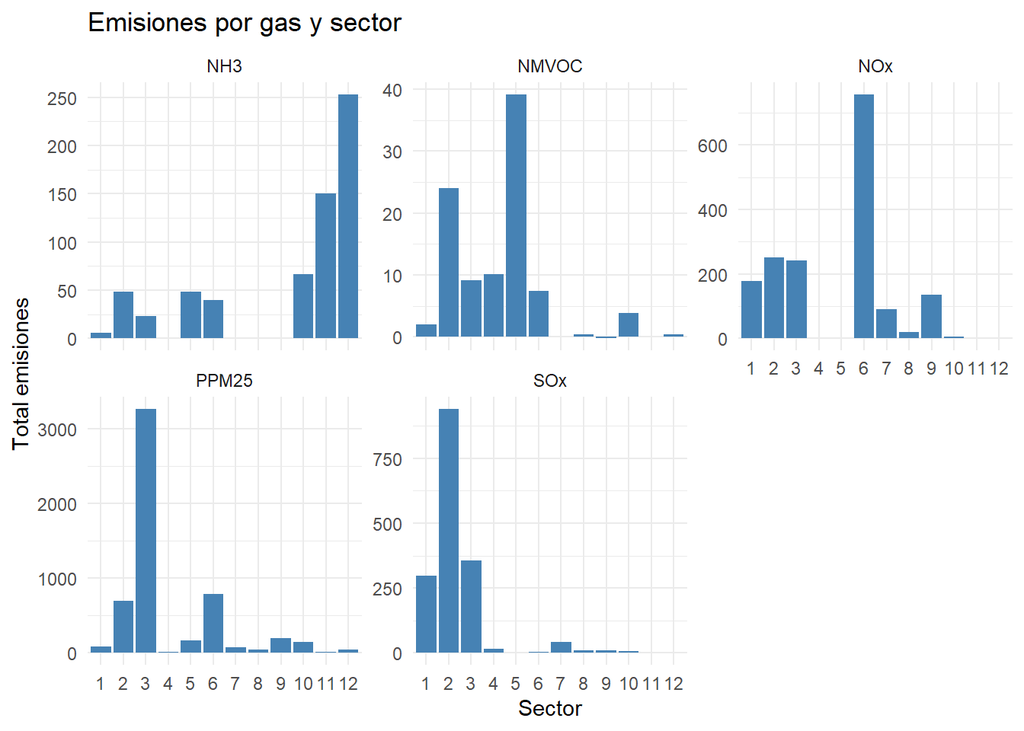

```r
ggplot(emisiones_por_sector, aes(x = factor(SECTOR), y = Total_Emisiones)) +
  geom_bar(stat = "identity", fill = "steelblue") +
  facet_wrap(~GAS, scales = "free_y") +
  labs(title = "Emisiones por gas y sector",
       x = "Sector",
       y = "Total emisiones") +
  theme_minimal()
```

**Principales contaminantes por sector**

1. PM2,5 (Material Particulado Fino): Emitido por todos los sectores aunque los que más lo emiten son: Combustión estacionaria, Transporte de carretera e Industria, con efectos en salud respiratoria.
2. NOₓ (Óxidos de Nitrógeno): Alto en Transporte de carretera, Energía pública e Industria, afectando directamente la calidad del aire urbano.
3. SOₓ (Óxidos de Azufre): Proviene principalmente de la Industria, la Energía pública y combustión estacionaria, también presente en Transporte Marítimo, contribuyendo a la lluvia ácida.

5. NMVOC (Compuestos Orgánicos Volátiles No Metánicos): Se asocia fuertemente con Solvents (disolventes) y la Industria.

#### Heatmap: intensidad de gases por sector

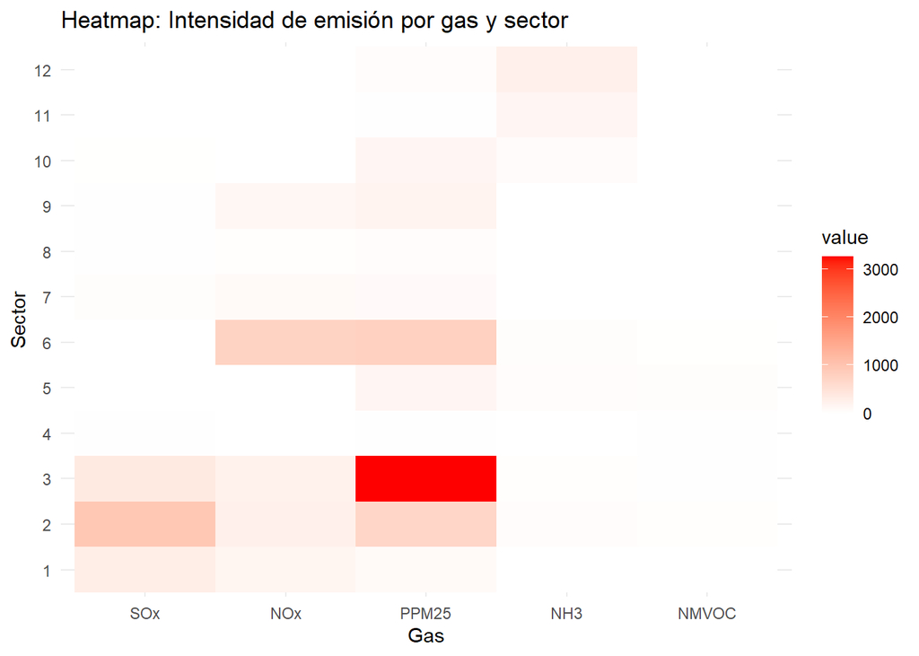

```r
library(ggplot2)
library(reshape2)

# Convertir a matriz para heatmap
heat_data <- emisiones_por_sector %>%
  pivot_wider(names_from = GAS, values_from = Total_Emisiones, values_fill = 0)

# Convertir a formato largo para ggplot
heat_data_long <- melt(heat_data, id.vars = "SECTOR")

ggplot(heat_data_long, aes(x = variable, y = factor(SECTOR), fill = value)) +
  geom_tile() +
  scale_fill_gradient(low = "white", high = "red") +
  labs(title = "Heatmap: Intensidad de emisión por gas y sector",
       x = "Gas",
       y = "Sector") +
  theme_minimal()
```

# PCA DE EMISIONES POR SECTOR

```r
# Objetivo: Cuantificar y caracterizar la contaminación generada por los principales sectores en Europa.

# 1. Carga de Librerías

library(readxl)
library(dplyr)
library(tidyr)
library(FactoMineR) # Para la función PCA
```

```r
library(factoextra) # Para visualizaciones de PCA (fviz_pca_*, fviz_eig, fviz_contrib)
library(ggplot2)
library(knitr)      # Para tablas bonitas (kable)
library(reshape2)   # Para el heatmap (melt)


library(mice) # Para imputación de valores faltantes (aunque para los datos actuales no es estrictamente necesario pq ya están limpios)
library(gridExtra) # Para organizar gráficos en cuadrícula (grid.arrange)
# 2. Lectura y Preparación de Datos

df <- read_excel("gases_city.xlsx")

# Convertir la columna POTENCIAL a numérica, reemplazando comas por puntos
df <- df %>%
  mutate(POTENCIAL = as.numeric(gsub(",", ".", POTENCIAL)))

# Crear la matriz para el PCA: Resumir las emisiones sumando por SECTOR y GAS.
# Cada fila será un SECTOR, cada columna un GAS, y los valores serán las emisiones totales.
matriz_pca <- df %>%
  group_by(SECTOR, GAS) %>%
  summarise(Emisiones = sum(POTENCIAL, na.rm = TRUE)) %>% # Sumar emisiones por cada combinación sector-gas
  pivot_wider(names_from = GAS, values_from = Emisiones, values_fill = 0) # Transformar a formato ancho
# Preparar los datos numéricos para el PCA
# Guardar los nombres de los sectores para usarlos como etiquetas
nombres_sectores <- matriz_pca$SECTOR
datos_pca_num <- matriz_pca[, -1] # Excluir la columna 'SECTOR' que es categórica


# Verificar si hay variables con varianza cero y eliminarlas
datos_pca_num <- datos_pca_num[, apply(datos_pca_num, 2, var, na.rm = TRUE) != 0]

# Definición de los nombres de los sectores (tal como los tienes en tu Rmd) ---
# Esto es útil para una mejor interpretación de los gráficos finales.
nombres_legibles_sectores <- c(
  "Energía Pública", "Industria", "Otra combustión estacionaria", "Fugitivos",
  "Disolventes", "Transporte de carretera", "Transporte marítimo", "Aviación",
  "Transportate todoterreno", "Residuos", "Agricultura y ganadería", "Otra agricultura"
)
```

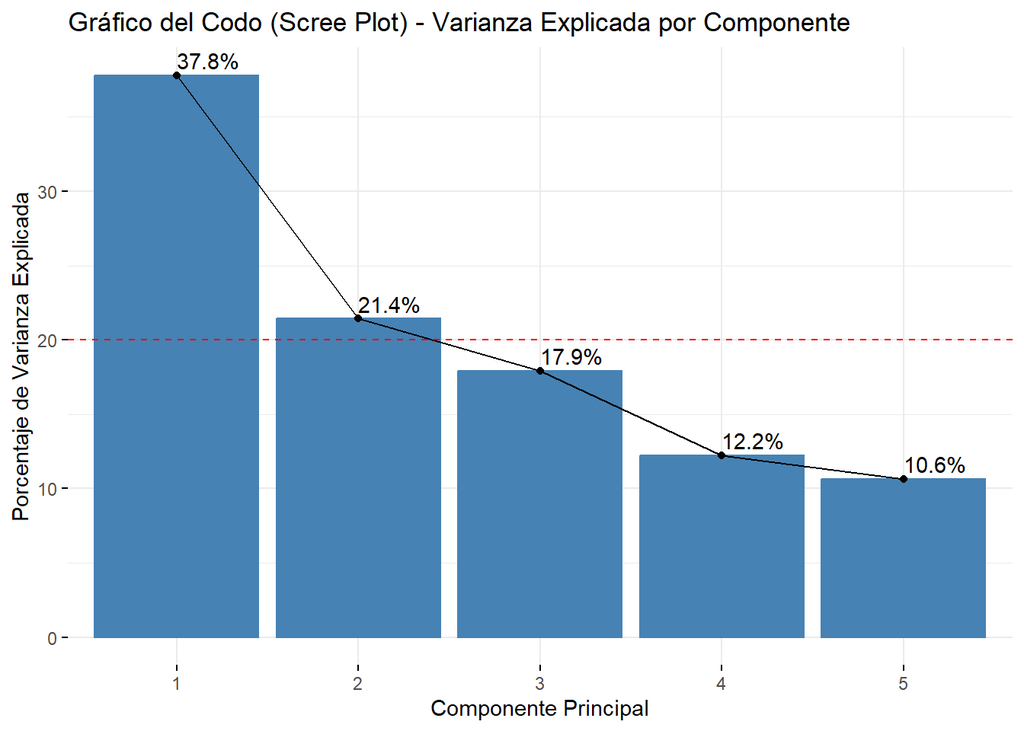

```r
# 3. Selección del Número de Componentes Principales (PCs)


# Ejecutar PCA con un número elevado de componentes para evaluar su importancia.
# scale.unit = TRUE: Centrar y escalar (estandarizar) las variables.
# graph = FALSE: No generar gráficos automáticamente.
# ncp = número_máximo_de_componentes (min(nrow-1, ncol)).

res.pca_completo <- PCA(datos_pca_num, scale.unit = TRUE, graph = FALSE, ncp = min(nrow(datos_pca_num)-1, ncol(datos_pca_num)))

# Obtener los valores propios (eigenvalues)
eig.val <- get_eigenvalue(res.pca_completo)

# Calcular la varianza explicada media por PC
# (Criterio Kaiser o "varianza media")
VPmedio = 100 * (1/nrow(eig.val))

# Gráfico del codo (scree plot)
fviz_eig(res.pca_completo, addlabels = TRUE) +
  geom_hline(yintercept=VPmedio, linetype=2, color="red") +
  labs(title = "Gráfico del Codo (Scree Plot) - Varianza Explicada por Componente") +
  xlab("Componente Principal") +
  ylab("Porcentaje de Varianza Explicada")
```

```r
# Mostrar tabla de valores propios
kable(eig.val)
```

|  | eigenvalue | variance.percent | cumulative.variance.percent |
| --- | --- | --- | --- |
| Dim.1 | 1.8904149 | 37.80830 | 37.80830 |
| Dim.2 | 1.0710553 | 21.42111 | 59.22941 |
| Dim.3 | 0.8954177 | 17.90835 | 77.13776 |
| Dim.4 | 0.6116583 | 12.23317 | 89.37093 |
| Dim.5 | 0.5314537 | 10.62907 | 100.00000 |

```r
# --- Selección de 2 PCs ---

# Basándonos en el gráfico del codo y el criterio de la varianza media (línea roja), podemos decidir cuántas PCs son "óptimas" : 2
K = 2

# Re-ejecutar PCA con el número K de componentes principales seleccionadas
res.pca <- PCA(datos_pca_num, scale.unit = TRUE, graph = FALSE, ncp = K)

cat(paste0("Se seleccionan ", K, " PCs, que explican un ",
           round(eig.val[K,"cumulative.variance.percent"], 1), "% del total de variabilidad de los datos."))
```

```
## Se seleccionan 2 PCs, que explican un 59.2% del total de variabilidad de los datos.
```

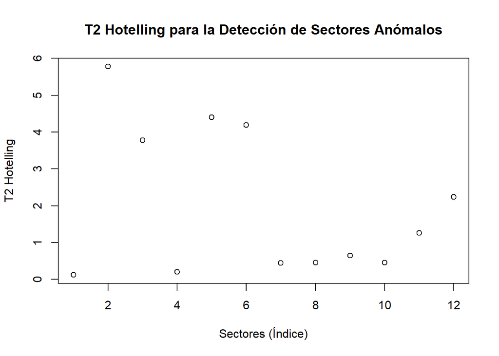

```r
# 4. Validación del Modelo PCA (Detección de Anómalos)

# --- 4.1. Detección de Anómalos con T2-Hotelling

# Este estadístico mide la distancia de cada observación al centro del modelo PCA en el espacio de las K PCs.

misScores = res.pca$ind$coord[,1:K]
miT2 = colSums(t(misScores**2)/eig.val[1:K,1])

I = nrow(datos_pca_num) # Número de observaciones (sectores)
F95 = K*(I**2 - 1)/(I*(I - K)) * qf(0.95, K, I-K)
F99 = K*(I**2 - 1)/(I*(I - K)) * qf(0.99, K, I-K)

plot(1:length(miT2), miT2, type = "p", xlab = "Sectores (Índice)", ylab = "T2 Hotelling",
     main = "T2 Hotelling para la Detección de Sectores Anómalos")
abline(h = F95, col = "orange", lty = 2, lwd = 2) # Límite del 95%
abline(h = F99, col = "red3", lty = 2, lwd = 2)   # Límite del 99%
```

```r
anomalas_idx = which(miT2 > F95)

cat(paste0("Hay ", length(anomalas_idx), " sectores anómalos que superan el límite del 95%."))
```

```
## Hay 0 sectores anómalos que superan el límite del 95%.
```

```r
if (length(anomalas_idx) > 0) {
  cat(paste0("Sectores anómalos (por índice): ", paste(anomalas_idx, collapse = ", ")))
  cat(paste0("Nombres de sectores anómalos: ", paste(nombres_legibles_sectores[anomalas_idx], collapse = ", ")))
}
```

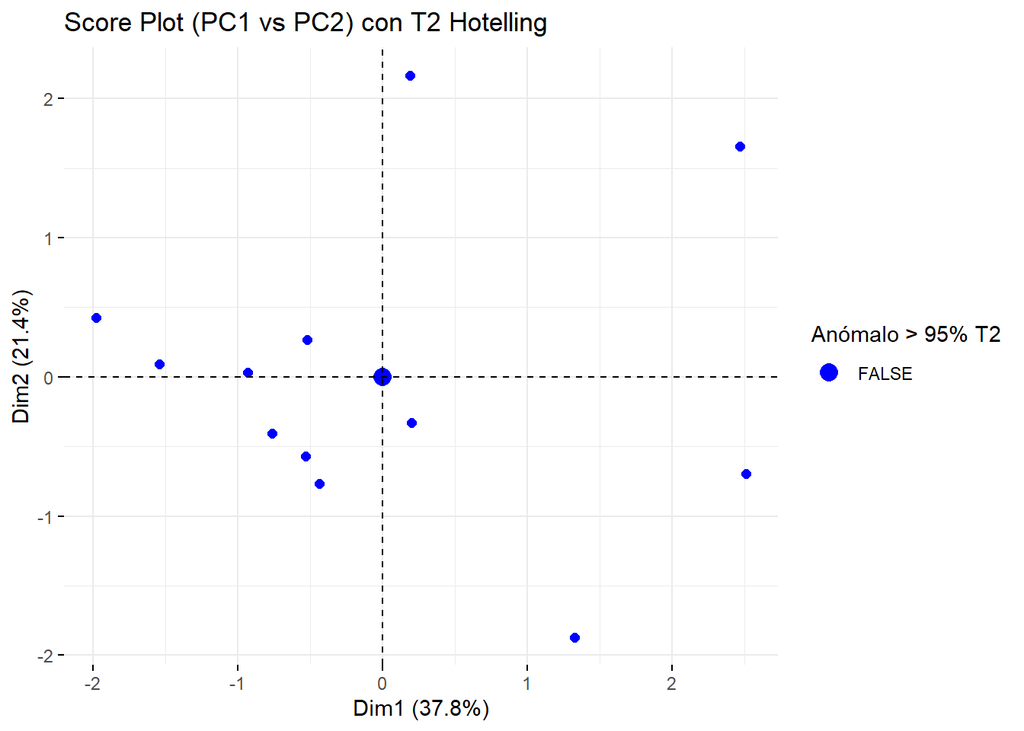

```r
# --- Visualización de Scores (individuos) coloreados por anomalía

p1_T2 = fviz_pca_ind(res.pca, axes = c(1,2), geom = c("point"),
                  habillage = factor(miT2 > F95),
                  pointshape = 20, pointsize = 3,
                  repel = TRUE, # Evita la superposición de etiquetas
                  labelsize = 3) +
  scale_color_manual(values = c("TRUE" = "red", "FALSE" = "blue"),
                     name = "Anómalo > 95% T2") +
  labs(title = "Score Plot (PC1 vs PC2) con T2 Hotelling")
 gridExtra::grid.arrange(p1_T2, nrow = 1)
```

Aparentemente, al considerar solo las dos primeras componentes principales, ningún sector se clasifica como anómalo por el criterio T2 Hotelling al 95%.

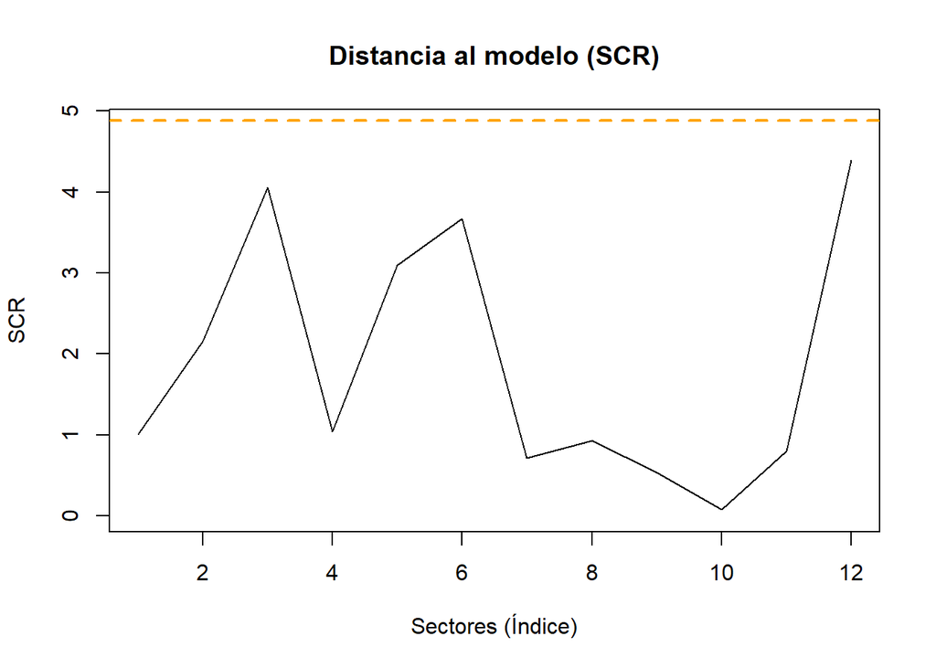

```r
# --- 4.2. Distancia al Modelo (SCR - Suma de Cuadrados Residuales)

# Detecta anomalías moderadas o observaciones no bien explicadas por el modelo.
# Primero, necesitamos los datos centrados y escalados que usó PCA.

X_scaled <- scale(datos_pca_num, center = TRUE, scale = TRUE)


misLoadings <- sweep(res.pca$var$coord, 2, sqrt(res.pca$eig[1:K,1]), FUN="/")

# Calcular la matriz de residuos
myE = X_scaled - misScores %*% t(misLoadings)
mySCR = rowSums(myE^2) # SCR para cada observación (fila)

plot(1:length(mySCR), mySCR, type = "l", main = "Distancia al modelo (SCR)",
     ylab = "SCR", xlab = "Sectores (Índice)", ylim = c(0, max(mySCR) * 1.1))

# Límites de control basados en distribución Chi-cuadrado (aproximación)
g = var(mySCR)/(2*mean(mySCR))
h = (2*mean(mySCR)^2)/var(mySCR)
chi2lim95 = g*qchisq(0.95, df = h)
chi2lim99 = g*qchisq(0.99, df = h)

abline(h = chi2lim95, col = "orange", lty = 2, lwd = 2)
abline(h = chi2lim99, col = "red3", lty = 2, lwd = 2)
```

```r
anomalas_scr_95_idx = which(mySCR > chi2lim95)
anomalas_scr_99_idx = which(mySCR > chi2lim99)

cat(paste0("Hay ", sum(mySCR > chi2lim95), " sectores que superan el límite del 95% en SCR."))
```

```
## Hay 0 sectores que superan el límite del 95% en SCR.
```

```r
if (length(anomalas_scr_95_idx) > 0) {
  cat(paste0("Sectores anómalos por SCR (95%): ", paste(nombres_legibles_sectores[anomalas_scr_95_idx], collapse = ", ")))
}
cat(paste0("Hay ", sum(mySCR > chi2lim99), " sectores que superan el límite del 99% en SCR."))
```

```
## Hay 0 sectores que superan el límite del 99% en SCR.
```

```r
if (length(anomalas_scr_99_idx) > 0) {
  cat(paste0("Sectores anómalos por SCR (99%): ", paste(nombres_legibles_sectores[anomalas_scr_99_idx], collapse = ", ")))
}
```

La mayoría de los sectores muestran valores de SCR relativamente bajos y estables.

El Sector 3 (Other stationary combustion) muestra un pico de SCR notable (alrededor de 4.1). El Sector 12 (Agriculture other) presenta un valor de SCR elevado (alrededor de 4.4). El Sector 6 (Road transportation) también presenta un valor elevado de SCR, pero menor que el 3 y 12.

Conclusión: El Sector 3 (Other stationary combustion) y el Sector 12 (Agriculture other) son los que el modelo PCA explica peor. Sus perfiles de emisión tienen características que no son completamente capturadas por las dos componentes principales.

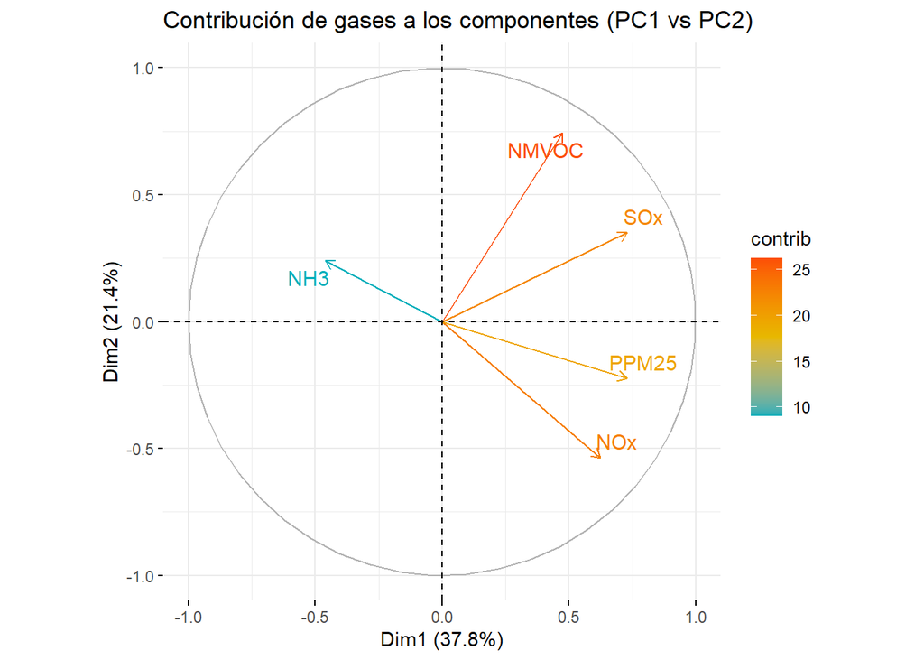

```r
# 5. Interpretación del Modelo PCA

# --- 5.1. Gráficos de Variables (Loadings)
# Muestra cómo los gases contribuyen a las dimensiones y sus correlaciones.
# Coloreado por contribución a las PCs representadas

fviz_pca_var(res.pca, axes = c(1,2), repel = TRUE, col.var = "contrib",
             gradient.cols = c("#00AFBB", "#E7B800", "#FC4E07"),
             title = "Contribución de gases a los componentes (PC1 vs PC2)")
```

Este es el círculo de correlación de variables. Muestra cómo los gases (variables) se correlacionan con las dos primeras componentes principales y entre sí.

PRIMERA PC El eje horizontal. Los gases SOx, PPM25 y NOx tienen flechas largas que apuntan hacia la derecha. Esto indica una fuerte correlación positiva con Dim1 y entre ellos. Esta componente representa la variabilidad asociada con los contaminantes de la combustión, la industria y el transporte.

SEGUNDA PC El eje vertical. NMVOC tiene una flecha larga que apunta hacia arriba, lo que significa una fuerte correlación positiva con Dim2. SOx también tiene una componente positiva en Dim2, lo que sugiere su relación con procesos industriales que también emiten NMVOC.

NH3: Su flecha apunta hacia la izquierda (PC negativa). Esto indica que NH3 se correlaciona negativamente con los gases de combustión/industria (PPM25, NOx, SOx). Esto es coherente con su origen agrícola, que lo distingue de las fuentes de los otros gases.

CONCLUSIÓN: Las dos primeras componentes principales resumen claramente los patrones de emisión: una relacionada con contaminantes de combustión/industria/transporte y otra con emisiones de compuestos orgánicos volátiles (NMVOC). NH3 se desmarca de ambos grupos.

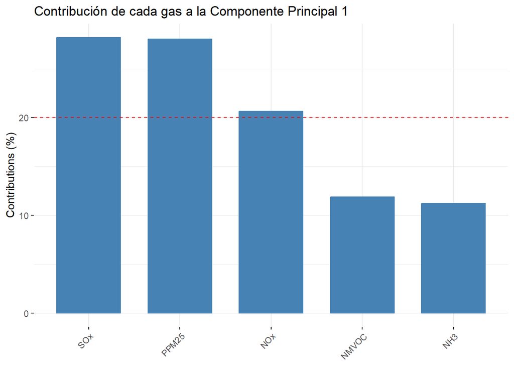

```r
# Gráfico de barras de contribución por PC (para entender qué variables son más importantes para cada PC individualmente)
fviz_contrib(res.pca, choice = "var", axes = 1, top = ncol(datos_pca_num),
             title = "Contribución de cada gas a la Componente Principal 1")
```

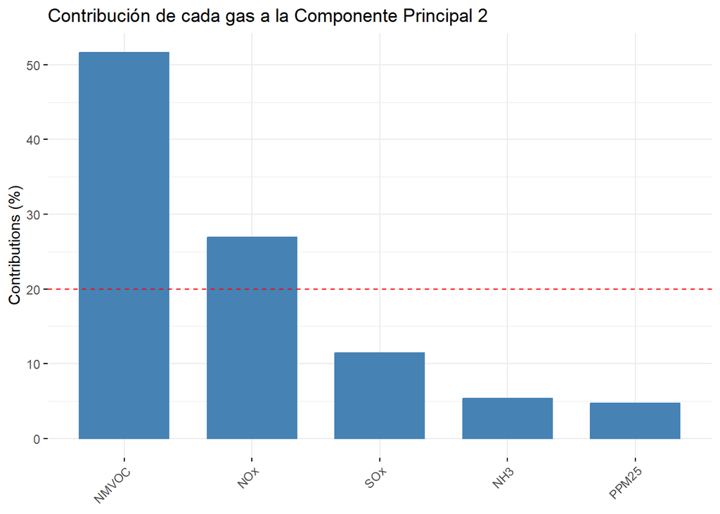

```r
fviz_contrib(res.pca, choice = "var", axes = 2, top = ncol(datos_pca_num),
             title = "Contribución de cada gas a la Componente Principal 2")
```

La PC1 es una “dimensión” de contaminación por SOx, PM2.5 y NOx, predominantemente. La PC2 es principalmente una “dimensión” de contaminación por NMVOC, con una contribución secundaria de NOx y SOx.

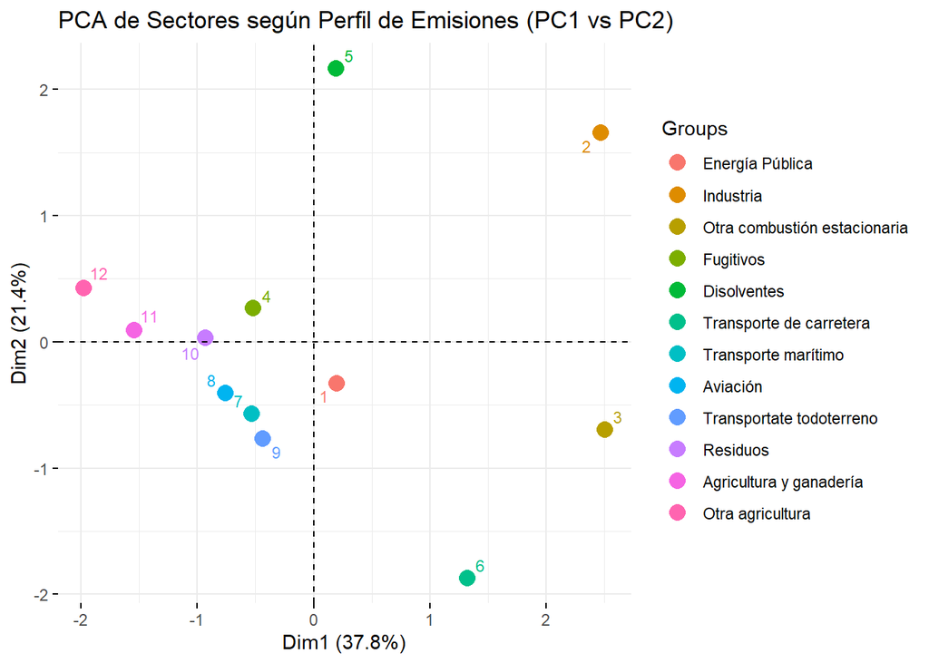

```r
# --- 5.2. Gráficos de Observaciones (Score Plot)

# Muestra cómo se agrupan los sectores en el espacio de las componentes principales.
# Usaremos los nombres legibles de los sectores.
# Crea un factor con los nombres de los sectores para etiquetar correctamente
etiquetas_sectores <- factor(nombres_sectores, levels = nombres_sectores, labels = nombres_legibles_sectores)

fviz_pca_ind(res.pca, axes = c(1,2), geom = c("point", "text"),
             habillage = etiquetas_sectores, # Color por sector (si hay pocos, si no, agrupa por algo más)
             col.ind = "darkblue", # Puedes elegir un color si no quieres diferenciar por 'habillage'
             pointshape = 20, pointsize = 3,
             repel = TRUE, # Evita la superposición de etiquetas
             labelsize = 3,
             title = "PCA de Sectores según Perfil de Emisiones (PC1 vs PC2)")
```

```r
# Puedes añadir elipses de confianza si quieres agrupar los sectores por alguna característica auxiliar
# Por ejemplo, si tuvieras una variable de "Tipo de Sector" (ej. "Transporte", "Industria", "Agricultura")
# fviz_pca_ind(res.pca, axes = c(1,2), geom = c("point", "text"),
#              habillage = TU_VARIABLE_AUXILIAR_DE_TIPO_DE_SECTOR,
#              addEllipses = TRUE, ellipse.type = "convex",
#              repel = TRUE, labelsize = 3,
#              title = "PCA de Sectores por Tipo de Emisión con Elipses")
```

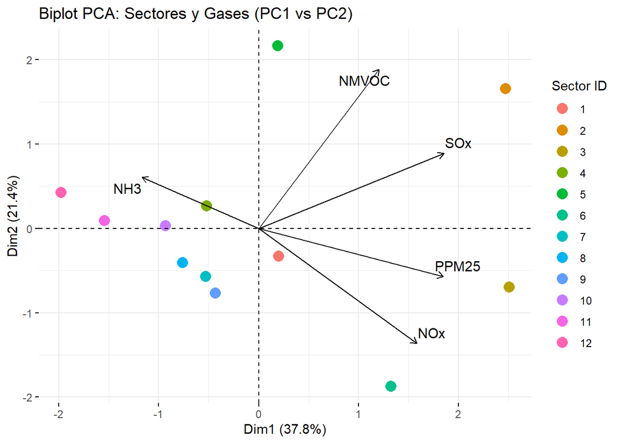

```r
# --- 5.3. Biplot (Variables y Observaciones Juntas)

# Combina el gráfico de variables y el de individuos. Útil para interpretar las relaciones.


fviz_pca_biplot(res.pca, axes = c(1,2),
                # Variables (gases)
                label = "var", # Mostrar etiquetas de las variables (gases)
                col.var = "black", # Color de las flechas de los gases
                repel = TRUE, # Evitar superposición de etiquetas de gases
                labelsize = 4,
                # Individuos (sectores)
                geom.ind = "point", # Mostrar los sectores como puntos
                pointshape = 20, pointsize = 3, # Estilo de los puntos de los sectores
                col.ind = as.factor(nombres_sectores), # Colorear los puntos de los sectores por su ID
                legend.title = "Sector ID",
                title = "Biplot PCA: Sectores y Gases (PC1 vs PC2)")
```

Este gráfico combina las observaciones (sectores, representados por puntos de colores) y las variables (gases, representados por flechas) en un mismo plano definido por PC1 y PC2.

Los sectores 2 (industria), 3(otros combustión estacionaria) y 6(transporte de carretera) se encuentran a la derecha del gráfico. Esto indica que estos sectores están fuertemente asociados con los gases SOx, PPM25 y NOx. Esta es la confirmación visual de que son los principales emisores de contaminantes de combustión/industria/transporte.

El Sector 5 (Solvents) se ubica en la parte superior del gráfico, muy cerca de la flecha de NMVOC. Esto demuestra que este sector es el principal emisor de NMVOC. El Sector 2 (Industry) también se encuentra en la parte superior derecha, lo que indica que, además de los gases de combustión, también emite NMVOC.

Los sectores 11 (Agricultura y ganadería) y 12 (Agriculture other) se agrupan claramente en el lado izquierdo del gráfico, cerca de la flecha de NH3. Esto confirma que estos sectores son los principales emisores de NH3 y que sus perfiles de emisión son distintos de los demás sectores.